# 2. 预备知识

Deep Learning I

2. 预备知识

WU Xiaokun 吴晓堃

xkun.wu [at] gmail

2021/02/28

# 数据操作

## N维数组

也称为**张量 tensor**

- `Numpy`的`ndarray`：仅支持CPU计算
- `PyTorch`和`TensorFlow`中`Tensor`：支持自动微分

难点：

- 理解**维度、形状与索引**
- 理解**张量的构造**
  - 增减维度
  - 拼接

## 几个常见特例

0-d（标量）

```
1.0
```

- 类别

1-d（向量）

```
[1.0, 2.7, 3.4]
```

- 特征向量

2-d（矩阵）

```
[
    [1.0, 2.7, 3.4]
    [5.0, 0.2, 4.6]
    [4.3, 8.5, 0.2]
]
```

- 样本-特征矩阵

## 几个应用特例

3-d

```
[[[0.1, 2.7, 3.4]
 [5.0, 0.2, 4.6]
 [4.3, 8.5, 0.2]]
 [[3.2, 5.7, 3.4]
 [5.4, 6.2, 3.2]
 [4.1, 3.5, 6.2]]]

[
    [
        [0.1, 2.7, 3.4]
        [5.0, 0.2, 4.6]
        [4.3, 8.5, 0.2]
    ]
    [
        [3.2, 5.7, 3.4]
        [5.4, 6.2, 3.2]
        [4.1, 3.5, 6.2]
    ]
]
```

- RGB图片（通道x宽x高）

4-d

```
[[[[. . .
 . . .
 . . .]]]]
```

- 批量RGB图片（批量x通道x宽x高）

5-d

```
[[[[[. . .
 . . .
 . . .]]]]]
```

- 批量视频（批量x时间x通道x宽x高）

## 实验：N维数组

# 数据预处理

## pandas软件包

Pandas (Python Data Analysis Library)

- Python 的**核心数据分析支持库**，提供了快速、灵活、明确的数据结构，旨在简单、直观地处理关系型、标记型数据。

## 实验：pandas软件包

# 线性代数

## 几何意义：向量

两种解释

- 位置：坐标系上，与原点的相对距离
  - 标准正交基的**线性组合**
- 方向和长度

向量加法：连接起点、终点

向量内积：度量**相似度**

- 投影后相乘：$a \cdot b = |a|(|b|\cos \theta)$

## 矩阵乘法

行列维数需要一致

注意：Python中`*`默认是**按元素乘法**

- 数学上的Hadamard积：$\odot$

## 几何意义：矩阵

矩阵乘法：**空间线性变形**

- 矩阵乘以矩阵可以看成矩阵乘以多个列向量
  - 特例：标准正交基，即坐标系
- 仿射变换

$$\begin{bmatrix}
m_{00} & m_{01} & t_x \\
m_{10} & m_{11} & t_y \\
0 & 0 & 1
\end{bmatrix}$$

## 矩阵的特征向量

不被此矩阵改变方向

$$Ax = \lambda x$$

## 实验：线性代数

# Halftime

# 多元微分

## 标量导数

一元微分（**标量对标量**）

- 基本函数：

| $y$ | $a$ | $x^n$ | $\exp(x)$ | $\log(x)$ | $\sin(x)$ |
| --- | --- | --- | --- | --- | --- |
| $\frac{dy}{dx}$ | $0$ | $nx^{n-1}$ | $\exp(x)$ | $\frac{1}{x}$ | $\cos(x)$ |

- 复合函数：

| $y$ | $u+v$ | $uv$ | $y=f(u), u=g(x)$ |
| --- | --- | --- | --- |
| $\frac{dy}{dx}$ | $\frac{du}{dx} + \frac{dv}{dx}$ | $\frac{du}{dx}v + \frac{dv}{dx}u$ | $\frac{dy}{du}\frac{du}{dx}$ |

## 梯度

多元微分（**标量对向量**）

$$df = \sum_i \frac{\partial f}{\partial x_i} dx_i = \frac{\partial f}{\partial x} d\mathbf{x}$$

- 全微分公式；梯度向量与微分向量的内积
- 微分：$d\mathbf{x} = [dx_1, dx_2, .., dx_n]^T$
- （偏）导数：$\frac{\partial}{\partial \mathbf{x}} = [\frac{\partial}{\partial x_1}, \frac{\partial}{\partial x_2}, .., \frac{\partial}{\partial x_n}]$
  - “梯度横着走”

## 雅可比矩阵 Jacobian matrix

多元微分（**向量对向量**）

$$\mathbf{x} =
\begin{bmatrix}
x_1\\
x_2\\
\vdots\\
x_n\\
\end{bmatrix},
\mathbf{y} =
\begin{bmatrix}
y_1\\
y_2\\
\vdots\\
y_m\\
\end{bmatrix}$$

$$\frac{\partial \mathbf{y}}{\partial \mathbf{x}}
=
\begin{bmatrix}
\frac{\partial y_1}{\partial \mathbf{x}}\\
\frac{\partial y_2}{\partial \mathbf{x}}\\
\vdots\\
\frac{\partial y_m}{\partial \mathbf{x}}\\
\end{bmatrix}
=
\begin{bmatrix}
\frac{\partial y_1}{\partial x_1}, \frac{\partial y_1}{\partial x_2}, \ldots, \frac{\partial y_1}{\partial x_n}\\
\frac{\partial y_2}{\partial x_1}, \frac{\partial y_2}{\partial x_2}, \ldots, \frac{\partial y_2}{\partial x_n}\\
\vdots, \vdots, \ddots, \vdots\\
\frac{\partial y_m}{\partial x_1}, \frac{\partial y_m}{\partial x_2}, \ldots, \frac{\partial y_m}{\partial x_n}\\
\end{bmatrix}$$

## 特例

多元微分（**向量对标量**）

$$\mathbf{y} =
\begin{bmatrix}
y_1\\
y_2\\
\vdots\\
y_m\\
\end{bmatrix},
\frac{\partial \mathbf{y}}{\partial x} =
\begin{bmatrix}
\frac{\partial y_1}{\partial x}\\
\frac{\partial y_2}{\partial x}\\
\vdots\\
\frac{\partial y_m}{\partial x}\\
\end{bmatrix}$$

- $\frac{\partial y}{\partial \mathbf{x}}$是行向量，$\frac{\partial \mathbf{y}}{\partial x}$是列向量
  - 只是其中一种约定方式

## 规律

|  | $x:(1,)$ | $\mathbf{x}:(n,1)$ |
| --- | --- | --- |
| $y:(1,)$ | $\frac{\partial y}{\partial x}:(1,)$ | $\frac{\partial y}{\partial \mathbf{x}}:(1,n)$ |
| $\mathbf{y}:(m,1)$ | $\frac{\partial \mathbf{y}}{\partial x}:(m,1)$ | $\frac{\partial \mathbf{y}}{\partial \mathbf{x}}:(m,n)$ |

- $x$逆序排
- 先排$y$，再排$x$

聪明的数学家非常善于提取、总结客观规律

- 微分学被系统地搭建起来
- 高度抽象的概念需要大量的**标记符**来概括描述
  - 于是本来没有的**问题被创造出来**
- 更聪明的物理学家想出了简化标记

## 拓展到矩阵

|  | $x:(1,)$ | $\mathbf{x}:(n,1)$ | $\mathbf{X}:(n,k)$ |
| --- | --- | --- | --- |
| $y:(1,)$ | $\frac{\partial y}{\partial x}:(1,)$ | $\frac{\partial y}{\partial \mathbf{x}}:(1,n)$ | $\frac{\partial y}{\partial \mathbf{X}}:(k,n)$ |
| $\mathbf{y}:(m,1)$ | $\frac{\partial \mathbf{y}}{\partial x}:(m,1)$ | $\frac{\partial \mathbf{y}}{\partial \mathbf{x}}:(m,n)$ | $\frac{\partial \mathbf{y}}{\partial \mathbf{X}}:(m,k,n)$ |
| $\mathbf{Y}:(m,l)$ | $\frac{\partial \mathbf{Y}}{\partial x}:(m,l)$ | $\frac{\partial \mathbf{Y}}{\partial \mathbf{x}}:(m,l,n)$ | $\frac{\partial \mathbf{Y}}{\partial \mathbf{X}}:(m,l,k,n)$ |

思考：矩阵是二维张量，拓展到N维张量？

## 实验：微分计算

# 自动微分

## 链式法则

$$y=f(u), u=g(x) \Rightarrow \frac{dy}{dx} = \frac{dy}{du}\frac{du}{dx}$$

手算举例：

$$z = (\langle \mathbf{x}, \mathbf{w} \rangle - y)^2, \frac{\partial z}{\partial \mathbf{w}} = ?$$

$$\begin{aligned}
a &= \langle \mathbf{x}, \mathbf{w} \rangle\\
b &= a - y\\
z &= b^2\\
\end{aligned}$$

$$\begin{aligned}
\frac{\partial z}{\partial \mathbf{w}} &= \frac{\partial z}{\partial b} \frac{\partial b}{\partial a} \frac{\partial a}{\partial \mathbf{w}}\\
&= 2b \cdot 1 \cdot \mathbf{x}^T\\
&= 2 (\langle \mathbf{x}, \mathbf{w} \rangle - y) \mathbf{x}^T\\
\end{aligned}$$

- 繁琐、易错；现在一般使用**自动微分**软件包

## 自动求导

构建**计算图**：将计算分解成算子的有向无环图

$$z = (\langle \mathbf{x}, \mathbf{w} \rangle - y)^2, \frac{\partial z}{\partial \mathbf{w}} = ?$$

$$\begin{aligned}
a &= \langle \mathbf{x}, \mathbf{w} \rangle\\
b &= a - y\\
z &= b^2\\
\end{aligned}$$

## 自动求导的两种模式

链式法则：

$$\frac{\partial y}{\partial x} = \frac{\partial y}{\partial u_n} \frac{\partial u_n}{\partial u_{n-1}} \cdots \frac{\partial u_2}{\partial u_1} \frac{\partial u_1}{\partial x}$$

- **前向积累 forward accumulation**：

$$\frac{\partial y}{\partial x} = \frac{\partial y}{\partial u_n} \left(\frac{\partial u_n}{\partial u_{n-1}} \left(\cdots \left(\frac{\partial u_2}{\partial u_1} \frac{\partial u_1}{\partial x}\right)\right)\right)$$

- **反向传递 backward propagation**：

$$\frac{\partial y}{\partial x} = \left(\left(\left(\frac{\partial y}{\partial u_n} \frac{\partial u_n}{\partial u_{n-1}}\right) \cdots\right) \frac{\partial u_2}{\partial u_1}\right) \frac{\partial u_1}{\partial x}$$

## 前向积累

前向：执行计算图，并**存储中间结果**

$$\begin{aligned}
a &= \langle \mathbf{x}, \mathbf{w} \rangle\\
b &= a - y\\
z &= b^2\\
\end{aligned}$$

## 反向传递 I

反向：**计算梯度值**，剪除不需要的枝，避免重复计算。

$$\begin{aligned}
z &= b^2\\
\end{aligned}$$

$$\begin{aligned}
\frac{\partial z}{\partial b} &= 2b\\
\end{aligned}$$

## 反向传递 II

反向：**计算梯度值**，剪除不需要的枝，避免重复计算。

$$\begin{aligned}
b &= a - y\\
\end{aligned}$$

$$\begin{aligned}
\frac{\partial b}{\partial a} &= 1\\
\end{aligned}$$

## 反向传递 III

反向：**计算梯度值**，剪除不需要的枝，避免重复计算。

$$\begin{aligned}
a &= \langle \mathbf{x}, \mathbf{w} \rangle\\
\end{aligned}$$

$$\begin{aligned}
\frac{\partial a}{\partial \mathbf{w}} &= \mathbf{x}^T\\
\end{aligned}$$

- 类比剪枝：剪除$y$对应的分支

## 为什么可以避免重复计算？

反向：**计算梯度值**，剪除不需要的枝，避免重复计算。

- 计算$\frac{\partial z}{\partial b}$需要$b$，进而需要$a$
- 类比：动态规划中的**查表**

## 实例：MLP 计算图

$$\begin{aligned}
\textbf{h} &= \sigma(\textbf{W}_h \textbf{x} + \textbf{b}_h)\\
\textbf{o} &= \textbf{W}_o \textbf{h} + \textbf{b}_o\\
s &= \frac{\lambda}{2} \left( \lVert \textbf{W}_h \rVert_F^2 + \lVert \textbf{W}_o \rVert_F^2 \right)\\
\end{aligned}$$

$$\begin{aligned}
\textbf{z} &= \textbf{W}_h \textbf{x}\\
\textbf{h} &= \phi(\textbf{z})\\
\textbf{o} &= \textbf{W}_o \textbf{h}\\
\mathcal{L} &= l(O,y)\\
\end{aligned}$$

## 实验：自动微分

# 优化

## 优化、泛化

**经验风险**是训练数据集的平均损失；而**风险**则是整个数据群的预期损失。

## 局部最小、全局最小

深度学习模型的目标函数通常有许多**局部最优解**。

$$f(x) = x \cdot \cos(\pi x), - 1.0 \le x \le 2.0$$

## 梯度下降

Taylor展开：函数的**一阶近似**

$$f(x + \epsilon) = f(x) + \epsilon f'(x) + O(\epsilon^2)$$

梯度：函数值**增长最快**的方向

- 向梯度的**反方向**走一小步
- $f(x - f'(x) \eta) \lessapprox f(x)$
- $x \leftarrow x - f'(x) \eta$

牛顿法：**二阶展开**，需要能够计算二阶导数（Hessian）

## 学习率

**学习率 learning rate**：$\eta$

- 太小：收敛慢
- 太大：发散

注意：地形平坦的区域步长自然变小

- $x \leftarrow x - f'(x) \eta$

## 带动量的梯度下降

摆脱**鞍点**：

摆脱**多个极小值**：

# Review

## 本章内容

张量，张量运算。 多元微分，自动求导。 链式求导：前向积累与反向传播。 基于梯度的优化。 实验：二维仿射变换。实验：基本激活函数。实验：ReLU合成法构造一般函数。

**重点**：张量、张量运算、三种基本激活函数、深度学习层间运算的一般形式；

**难点**：张量运算的几何解释、反向传播算法、基于梯度的优化、ReLU合成法、一致逼近理论。

## 学习目标

- 理解张量的概念；
- 掌握张量运算，并理解其几何解释；
- 理解基于梯度的优化及随机梯度下降算法；
- 理解反向传播算法的理论基础：链式求导法；
- 掌握三种基本激活函数：ReLU，Sigmoid，Tanh；
- 了解ReLU合成法构造连续函数的方法。

## 问题

(*) 列举5种基本的二维仿射变换，并应用于图片变形。

(*) 简述深度学习的几何解释。

(*) 假设$\mathbf{Y}$是$(a,b,c,d)$维张量，$\mathbf{X}$是$(h,i,j,k,l)$维张量，那么$\frac{\partial \mathbf{Y}}{\partial \mathbf{X}}$的维度是多少？

画出$z = (\langle \mathbf{x}, \mathbf{w} \rangle - y)^2$的计算图，并使用前向积累和反向传递计算$\frac{\partial z}{\partial \mathbf{w}}$。

简述梯度下降法的算法流程。

## 概念

### 张量

数据的**容器**。0D、1D、2D张量又分别成为标量、向量、矩阵。

### 张量运算

数据不同表示之间的**变换函数**。

## 多元微分

**雅可比矩阵 Jacobian matrix**（向量对向量）

$$\frac{\partial \mathbf{y}}{\partial \mathbf{x}}
=
\begin{bmatrix}
\frac{\partial y_1}{\partial \mathbf{x}}\\
\frac{\partial y_2}{\partial \mathbf{x}}\\
\vdots\\
\frac{\partial y_m}{\partial \mathbf{x}}\\
\end{bmatrix}
=
\begin{bmatrix}
\frac{\partial y_1}{\partial x_1}, \frac{\partial y_1}{\partial x_2}, \ldots, \frac{\partial y_1}{\partial x_n}\\
\frac{\partial y_2}{\partial x_1}, \frac{\partial y_2}{\partial x_2}, \ldots, \frac{\partial y_2}{\partial x_n}\\
\vdots, \vdots, \ddots, \vdots\\
\frac{\partial y_m}{\partial x_1}, \frac{\partial y_m}{\partial x_2}, \ldots, \frac{\partial y_m}{\partial x_n}\\
\end{bmatrix}$$

矩阵微分：

|  | $x:(1,)$ | $\mathbf{x}:(n,1)$ | $\mathbf{X}:(n,k)$ |
| --- | --- | --- | --- |
| $y:(1,)$ | $\frac{\partial y}{\partial x}:(1,)$ | $\frac{\partial y}{\partial \mathbf{x}}:(1,n)$ | $\frac{\partial y}{\partial \mathbf{X}}:(k,n)$ |
| $\mathbf{y}:(m,1)$ | $\frac{\partial \mathbf{y}}{\partial x}:(m,1)$ | $\frac{\partial \mathbf{y}}{\partial \mathbf{x}}:(m,n)$ | $\frac{\partial \mathbf{y}}{\partial \mathbf{X}}:(m,k,n)$ |
| $\mathbf{Y}:(m,l)$ | $\frac{\partial \mathbf{Y}}{\partial x}:(m,l)$ | $\frac{\partial \mathbf{Y}}{\partial \mathbf{x}}:(m,l,n)$ | $\frac{\partial \mathbf{Y}}{\partial \mathbf{X}}:(m,l,k,n)$ |

## 反向传播算法

### 链式求导

将链式法则应用于神经网络梯度值的计算，得到的算法叫作**反向传播算法**。

- 计算梯度值，剪除不需要的枝，避免重复计算。

## 梯度下降法

### 优化目标

Objective: $\text{arg min}_{W, b} J$,

with: $J = \lVert \overline{y} - y \rVert, \overline{y} = \sum \textcolor{blue}{relu}(\textbf{W} \textcolor{blue}{*} x + \textbf{b})$

### 梯度下降更新

$W_1 = W_0 - \nabla J * s$

- 步长（学习率）要选取合适；
- 动量解决收敛速度、局部极值。

## 二维仿射变换

### 二维仿射变换的一般形式

$$\underline{GT} = \textbf{W} \textcolor{blue}{*} \underline{input} + \textbf{b}$$

### 基本二维仿射变换矩阵

$$\begin{bmatrix}
1 & 0 & 0 \\
0 & 1 & 0 \\
0 & 0 & 1
\end{bmatrix},
\begin{bmatrix}
1 & 0 & t_x \\
0 & 1 & t_y \\
0 & 0 & 1
\end{bmatrix},
\begin{bmatrix}
s_x & 0 & 0 \\
0 & s_y & 0 \\
0 & 0 & 1
\end{bmatrix},
\begin{bmatrix}
\cos(\theta) & \sin(\theta) & 0 \\
-\sin(\theta) & \cos(\theta) & 0 \\
0 & 0 & 1
\end{bmatrix},
\begin{bmatrix}
1 & e_x & 0 \\
e_y & 1 & 0 \\
0 & 0 & 1
\end{bmatrix}$$

## 深度学习的层间运算

### 深度学习层间运算的一般形式

$$\underline{output} = \textcolor{blue}{activate}(\underline{GT})$$
$$\underline{GT} = \textbf{W} \textcolor{blue}{*} \underline{input} + \textbf{b}$$

### 如何想象高维空间？

首先研究低维空间，归纳出规律，然后**将规律泛化到高维**。

## 深度学习的几何解释

### 深度学习可以解释为高维空间中非常复杂的几何变换

- 一切数据都是张量，即**几何空间中的点**。
- 模型的每一层对数据点做一个**几何变换**；而模型本身是这些变换的合成。
- 注意：几何变换必须可微。

### 模型的可探索空间（假设空间）需要足够大

只要模型的参数足够多，就能捕捉到原始数据中所有的映射关系。想象“$\Omega$路径”。

## 激活函数

### 三种基本激活函数

`ReLU`, `sigmoid`, `tanh`.

### 激活函数的作用

提供非线性。

## ReLU合成法

### ReLU 合成的一般形式

$$\sum \textcolor{blue}{relu}(\textbf{W} \textcolor{blue}{*} \underline{input} + \textbf{b})$$

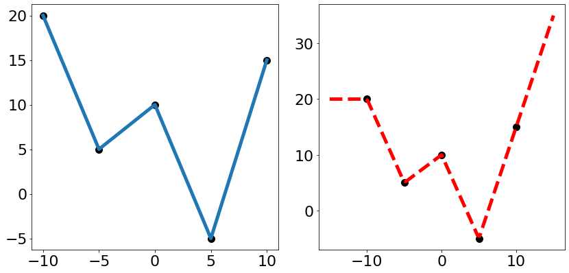

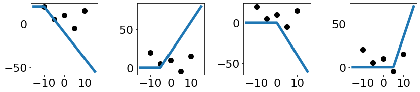

## 一致逼近原理

### Universal approximation theorem（非常有用的废话）

In approximation theory, both *shallow* and *deep* networks are known to **approximate any continuous functions** at an **exponential cost**.

构造方法：

- 构造线性函数；
- 构造分段线性函数；
- 构造离散化的任意函数。